# study1 preprocessing

anonymous

2024-12-10

```r
knit_by_pkgdown <- !is.null(knitr::opts_chunk$get("fig.retina"))
knitr::opts_chunk$set(
  warning = TRUE, # show warnings during codebook generation
  message = TRUE, # show messages during codebook generation
  error = TRUE, # do not interrupt codebook generation in case of errors,
                # TRUE is usually better for debugging
  echo = TRUE  # show R code
)

library(pacman)
pacman::p_load(tidyverse, here, codebook)
ggplot2::theme_set(ggplot2::theme_bw())
```

# 1 Read data

```r
codebook::codebook(d)
```

```
## No missing values.
```

### 1.0.1 Metadata

#### 1.0.1.1 Description

**Dataset name**: Dataset containing freesort minus causal scores from Study 1, to be used for selecting items for Study 2

This data set was generated by the study1_analysis.Rmd script. It contains item-pair-averaged freesort and causal distances. That is, this data was geneated after averaging the ratings for each item pair across subjects. There are 210 rows, corresponding to the 210 possible item pairs

**Metadata for search engines**

- **Date published**: 2025-02-03

| x |
| --- |
| itemA |
| itemB |
| domain_itemA |
| domain_itemB |
| mean_causal_distance |
| mean_freesort_distance |
| freesort_minus_causal |

## 1.1 Variables

### 1.1.1 itemA

The first item among item pairs in the study 1 Causal Task, which acts as the `cause` item

#### 1.1.1.1 Distribution

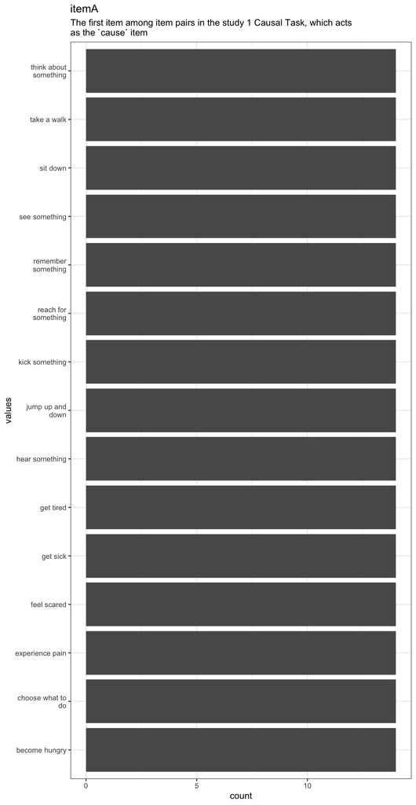

Distribution of values for itemA

0 missing values.

#### 1.1.1.2 Summary statistics

| name | label | data_type | n_missing | complete_rate | n_unique | empty | min | max | whitespace |
| --- | --- | --- | --- | --- | --- | --- | --- | --- | --- |
| itemA | The first item among item pairs in the study 1 Causal Task, which acts as the `cause` item | character | 0 | 1 | 15 | 0 | 8 | 21 | 0 |

### 1.1.2 itemB

The first item among item pairs in the study 1 Causal Task, which acts as the `effect` item

#### 1.1.2.1 Distribution

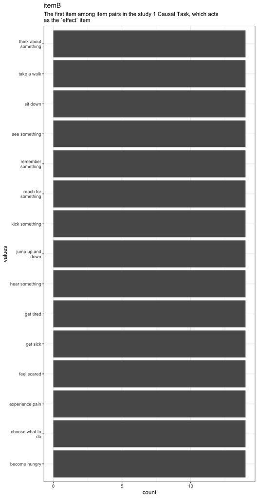

Distribution of values for itemB

0 missing values.

#### 1.1.2.2 Summary statistics

| name | label | data_type | n_missing | complete_rate | n_unique | empty | min | max | whitespace |
| --- | --- | --- | --- | --- | --- | --- | --- | --- | --- |
| itemB | The first item among item pairs in the study 1 Causal Task, which acts as the `effect` item | character | 0 | 1 | 15 | 0 | 8 | 21 | 0 |

### 1.1.3 domain_itemA

The domain of the first item in the pair, per RSA results of study 1

#### 1.1.3.1 Distribution

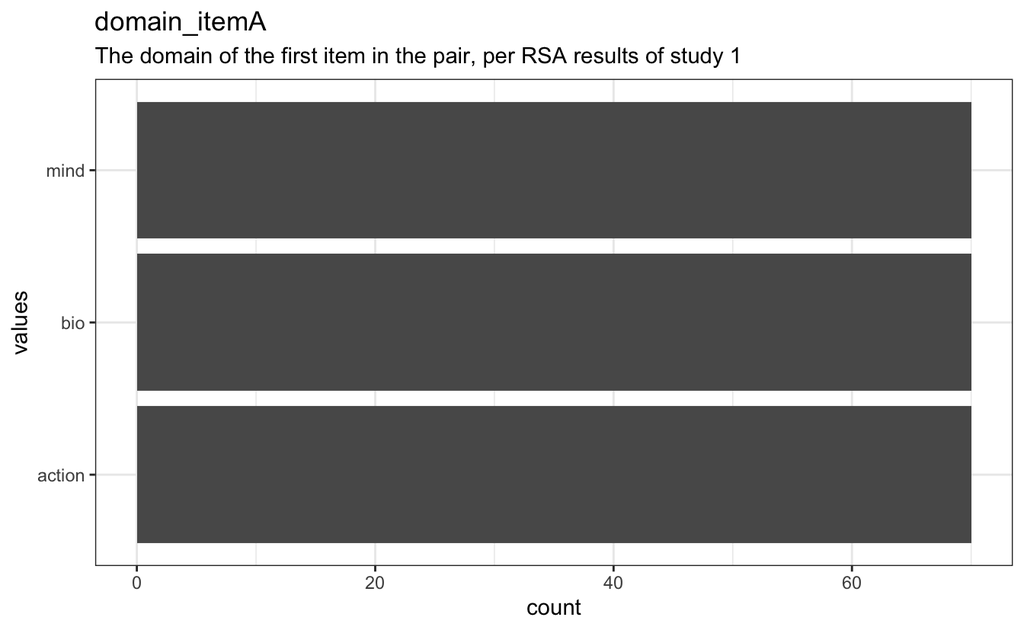

Distribution of values for domain_itemA

0 missing values.

#### 1.1.3.2 Summary statistics

| name | label | data_type | n_missing | complete_rate | n_unique | empty | min | max | whitespace |
| --- | --- | --- | --- | --- | --- | --- | --- | --- | --- |
| domain_itemA | The domain of the first item in the pair, per RSA results of study 1 | character | 0 | 1 | 3 | 0 | 3 | 6 | 0 |

### 1.1.4 domain_itemB

The domain of the second item in the pair, per RSA results of study 1

#### 1.1.4.1 Distribution

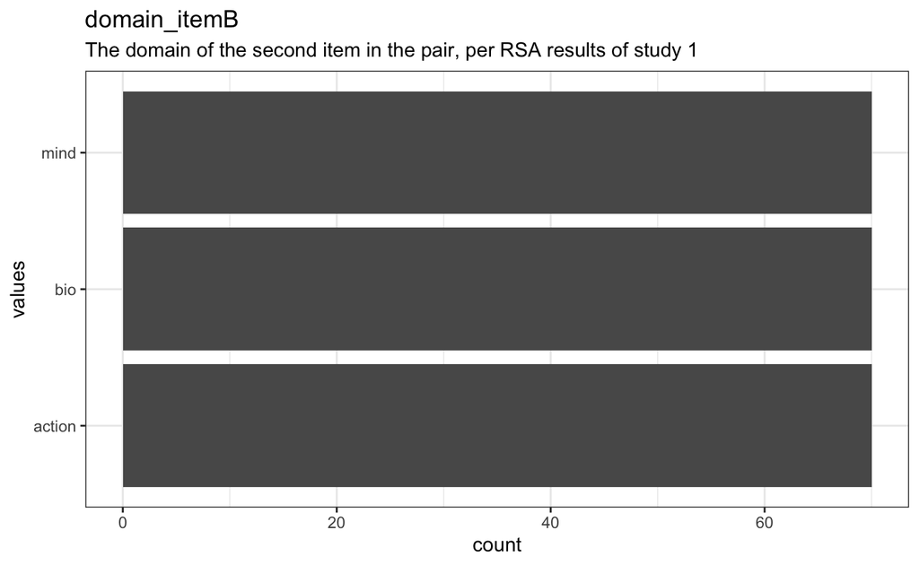

Distribution of values for domain_itemB

0 missing values.

#### 1.1.4.2 Summary statistics

| name | label | data_type | n_missing | complete_rate | n_unique | empty | min | max | whitespace |
| --- | --- | --- | --- | --- | --- | --- | --- | --- | --- |
| domain_itemB | The domain of the second item in the pair, per RSA results of study 1 | character | 0 | 1 | 3 | 0 | 3 | 6 | 0 |

### 1.1.5 mean_causal_distance

The mean causal distance between item A and item B

#### 1.1.5.1 Distribution

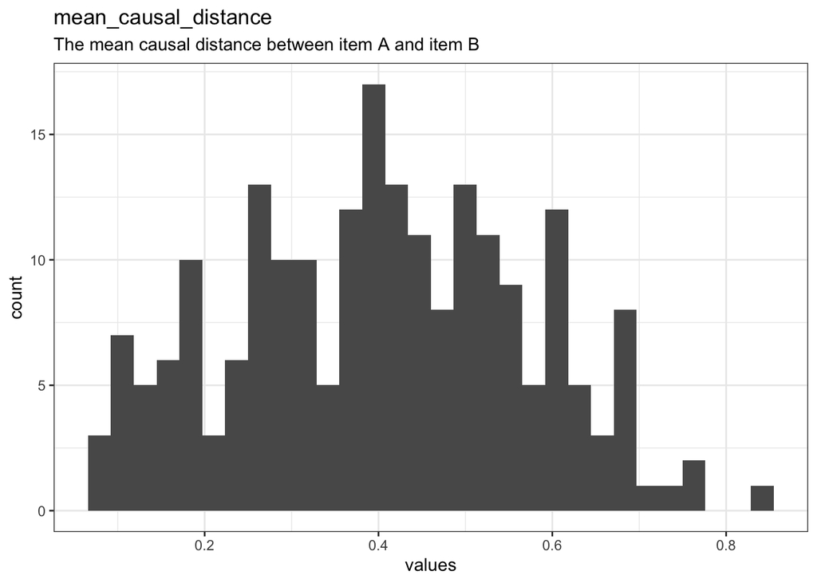

Distribution of values for mean_causal_distance

0 missing values.

#### 1.1.5.2 Summary statistics

| name | label | data_type | n_missing | complete_rate | min | median | max | mean | sd | hist |
| --- | --- | --- | --- | --- | --- | --- | --- | --- | --- | --- |
| mean_causal_distance | The mean causal distance between item A and item B | numeric | 0 | 1 | 0.079 | 0.4 | 0.84 | 0.4041933 | 0.1671079 | ▃▆▇▅▁ |

### 1.1.6 mean_freesort_distance

The mean freesort distance between item A and item B

#### 1.1.6.1 Distribution

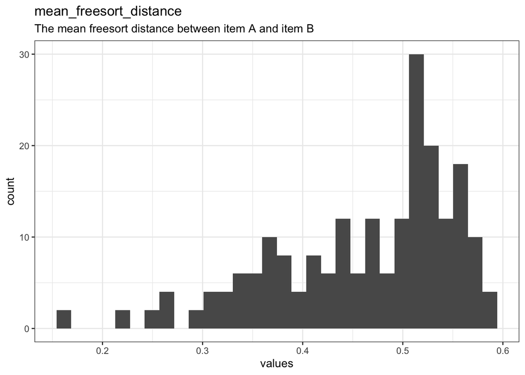

Distribution of values for mean_freesort_distance

0 missing values.

#### 1.1.6.2 Summary statistics

| name | label | data_type | n_missing | complete_rate | min | median | max | mean | sd | hist |
| --- | --- | --- | --- | --- | --- | --- | --- | --- | --- | --- |
| mean_freesort_distance | The mean freesort distance between item A and item B | numeric | 0 | 1 | 0.16 | 0.49 | 0.59 | 0.4615733 | 0.0909742 | ▁▁▃▅▇ |

### 1.1.7 freesort_minus_causal

The difference between the freesort distance and the causal distance

#### 1.1.7.1 Distribution

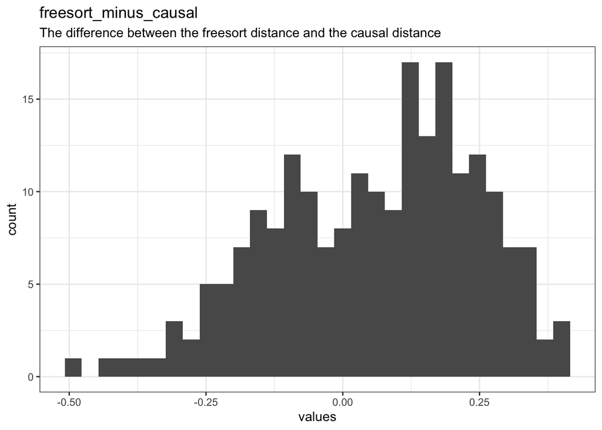

Distribution of values for freesort_minus_causal

0 missing values.

#### 1.1.7.2 Summary statistics

| name | label | data_type | n_missing | complete_rate | min | median | max | mean | sd | hist |
| --- | --- | --- | --- | --- | --- | --- | --- | --- | --- | --- |
| freesort_minus_causal | The difference between the freesort distance and the causal distance | numeric | 0 | 1 | -0.5 | 0.086 | 0.39 | 0.05738 | 0.1861072 | ▁▃▆▇▅ |